# Risk Factor Analysis

## Outcome Variable

**Outcome Variable:** haz

## Predictor Variables

**Intervention Variable:** feducyrs

**Adjustment Set:**

- arm
- W_mage
- meducyrs
- hhwealth_quart
- W_mhtcm
- W_mwtkg
- W_mbmi
- W_gagebrth
- W_birthwt
- W_birthlen
- single
- impsan
- delta_W_mage
- delta_meducyrs
- delta_hhwealth_quart
- delta_W_mhtcm
- delta_W_mwtkg
- delta_W_mbmi
- delta_W_gagebrth
- delta_W_birthwt
- delta_W_birthlen
- delta_single
- delta_impsan

## Stratifying Variables

The analysis was stratified on these variable(s):

- agecat
- studyid
- country

## Data Summary

| agecat | studyid | country | feducyrs | n_cell | n |
| --- | --- | --- | --- | --- | --- |
| Birth | ki0047075b-MAL-ED | BANGLADESH | High | 47 | 129 |
| Birth | ki0047075b-MAL-ED | BANGLADESH | Low | 36 | 129 |
| Birth | ki0047075b-MAL-ED | BANGLADESH | Medium | 46 | 129 |
| Birth | ki0047075b-MAL-ED | INDIA | High | 7 | 24 |
| Birth | ki0047075b-MAL-ED | INDIA | Low | 14 | 24 |
| Birth | ki0047075b-MAL-ED | INDIA | Medium | 3 | 24 |
| Birth | ki0047075b-MAL-ED | NEPAL | High | 3 | 10 |
| Birth | ki0047075b-MAL-ED | NEPAL | Low | 4 | 10 |
| Birth | ki0047075b-MAL-ED | NEPAL | Medium | 3 | 10 |
| Birth | ki0047075b-MAL-ED | PERU | High | 86 | 194 |
| Birth | ki0047075b-MAL-ED | PERU | Low | 58 | 194 |
| Birth | ki0047075b-MAL-ED | PERU | Medium | 50 | 194 |
| Birth | ki0047075b-MAL-ED | SOUTH AFRICA | High | 10 | 33 |
| Birth | ki0047075b-MAL-ED | SOUTH AFRICA | Low | 14 | 33 |
| Birth | ki0047075b-MAL-ED | SOUTH AFRICA | Medium | 9 | 33 |
| Birth | ki0047075b-MAL-ED | TANZANIA, UNITED REPUBLIC OF | High | 66 | 103 |
| Birth | ki0047075b-MAL-ED | TANZANIA, UNITED REPUBLIC OF | Low | 27 | 103 |
| Birth | ki0047075b-MAL-ED | TANZANIA, UNITED REPUBLIC OF | Medium | 10 | 103 |
| Birth | ki1000304b-SAS-CompFeed | INDIA | High | 299 | 1249 |
| Birth | ki1000304b-SAS-CompFeed | INDIA | Low | 543 | 1249 |
| Birth | ki1000304b-SAS-CompFeed | INDIA | Medium | 407 | 1249 |
| Birth | ki1017093b-PROVIDE | BANGLADESH | High | 163 | 539 |
| Birth | ki1017093b-PROVIDE | BANGLADESH | Low | 187 | 539 |
| Birth | ki1017093b-PROVIDE | BANGLADESH | Medium | 189 | 539 |
| Birth | ki1017093c-NIH-Crypto | BANGLADESH | High | 284 | 732 |
| Birth | ki1017093c-NIH-Crypto | BANGLADESH | Low | 235 | 732 |
| Birth | ki1017093c-NIH-Crypto | BANGLADESH | Medium | 213 | 732 |
| Birth | ki1113344-GMS-Nepal | NEPAL | High | 172 | 694 |
| Birth | ki1113344-GMS-Nepal | NEPAL | Low | 296 | 694 |
| Birth | ki1113344-GMS-Nepal | NEPAL | Medium | 226 | 694 |

[output cut: 135 more lines]

The following strata were considered:

- agecat: 24 months, studyid: ki0047075b-MAL-ED, country: BANGLADESH
- agecat: 24 months, studyid: ki0047075b-MAL-ED, country: INDIA
- agecat: 24 months, studyid: ki0047075b-MAL-ED, country: NEPAL
- agecat: 24 months, studyid: ki0047075b-MAL-ED, country: PERU
- agecat: 24 months, studyid: ki0047075b-MAL-ED, country: SOUTH AFRICA
- agecat: 24 months, studyid: ki0047075b-MAL-ED, country: TANZANIA, UNITED REPUBLIC OF
- agecat: 24 months, studyid: ki1017093b-PROVIDE, country: BANGLADESH
- agecat: 24 months, studyid: ki1017093c-NIH-Crypto, country: BANGLADESH
- agecat: 24 months, studyid: ki1066203-TanzaniaChild2, country: TANZANIA, UNITED REPUBLIC OF
- agecat: 24 months, studyid: ki1113344-GMS-Nepal, country: NEPAL
- agecat: 24 months, studyid: ki1119695-PROBIT, country: BELARUS
- agecat: 24 months, studyid: ki1126311-ZVITAMBO, country: ZIMBABWE
- agecat: 24 months, studyid: ki1135781-COHORTS, country: GUATEMALA
- agecat: 24 months, studyid: ki1135781-COHORTS, country: INDIA
- agecat: 24 months, studyid: ki1135781-COHORTS, country: PHILIPPINES
- agecat: 24 months, studyid: ki1148112-LCNI-5, country: MALAWI
- agecat: 24 months, studyid: kiGH5241-JiVitA-3, country: BANGLADESH
- agecat: 24 months, studyid: kiGH5241-JiVitA-4, country: BANGLADESH
- agecat: 6 months, studyid: ki0047075b-MAL-ED, country: BANGLADESH
- agecat: 6 months, studyid: ki0047075b-MAL-ED, country: INDIA
- agecat: 6 months, studyid: ki0047075b-MAL-ED, country: NEPAL
- agecat: 6 months, studyid: ki0047075b-MAL-ED, country: PERU
- agecat: 6 months, studyid: ki0047075b-MAL-ED, country: SOUTH AFRICA
- agecat: 6 months, studyid: ki0047075b-MAL-ED, country: TANZANIA, UNITED REPUBLIC OF
- agecat: 6 months, studyid: ki1000304b-SAS-CompFeed, country: INDIA
- agecat: 6 months, studyid: ki1000304b-SAS-FoodSuppl, country: INDIA
- agecat: 6 months, studyid: ki1017093b-PROVIDE, country: BANGLADESH
- agecat: 6 months, studyid: ki1017093c-NIH-Crypto, country: BANGLADESH
- agecat: 6 months, studyid: ki1066203-TanzaniaChild2, country: TANZANIA, UNITED REPUBLIC OF
- agecat: 6 months, studyid: ki1113344-GMS-Nepal, country: NEPAL
- agecat: 6 months, studyid: ki1119695-PROBIT, country: BELARUS
- agecat: 6 months, studyid: ki1126311-ZVITAMBO, country: ZIMBABWE
- agecat: 6 months, studyid: ki1135781-COHORTS, country: GUATEMALA
- agecat: 6 months, studyid: ki1135781-COHORTS, country: INDIA
- agecat: 6 months, studyid: ki1135781-COHORTS, country: PHILIPPINES
- agecat: 6 months, studyid: ki1148112-LCNI-5, country: MALAWI
- agecat: 6 months, studyid: kiGH5241-JiVitA-3, country: BANGLADESH
- agecat: 6 months, studyid: kiGH5241-JiVitA-4, country: BANGLADESH
- agecat: Birth, studyid: ki0047075b-MAL-ED, country: BANGLADESH
- agecat: Birth, studyid: ki0047075b-MAL-ED, country: INDIA
- agecat: Birth, studyid: ki0047075b-MAL-ED, country: NEPAL
- agecat: Birth, studyid: ki0047075b-MAL-ED, country: PERU
- agecat: Birth, studyid: ki0047075b-MAL-ED, country: SOUTH AFRICA
- agecat: Birth, studyid: ki0047075b-MAL-ED, country: TANZANIA, UNITED REPUBLIC OF
- agecat: Birth, studyid: ki1000304b-SAS-CompFeed, country: INDIA
- agecat: Birth, studyid: ki1017093b-PROVIDE, country: BANGLADESH
- agecat: Birth, studyid: ki1017093c-NIH-Crypto, country: BANGLADESH
- agecat: Birth, studyid: ki1113344-GMS-Nepal, country: NEPAL
- agecat: Birth, studyid: ki1119695-PROBIT, country: BELARUS
- agecat: Birth, studyid: ki1126311-ZVITAMBO, country: ZIMBABWE
- agecat: Birth, studyid: ki1135781-COHORTS, country: GUATEMALA
- agecat: Birth, studyid: ki1135781-COHORTS, country: INDIA
- agecat: Birth, studyid: ki1135781-COHORTS, country: PHILIPPINES
- agecat: Birth, studyid: kiGH5241-JiVitA-3, country: BANGLADESH
- agecat: Birth, studyid: kiGH5241-JiVitA-4, country: BANGLADESH

### Dropped Strata

Some strata were dropped due to rare outcomes:

- agecat: Birth, studyid: ki0047075b-MAL-ED, country: INDIA
- agecat: Birth, studyid: ki0047075b-MAL-ED, country: NEPAL
- agecat: 24 months, studyid: ki1066203-TanzaniaChild2, country: TANZANIA, UNITED REPUBLIC OF

## Methods Detail

We’re interested in the causal parameters $E[Y_a]$ for all values of $a \in \mathcal{A}$. These parameters represent the mean outcome if, possibly contrary to fact, we intervened to set all units to have $A=a$. Under the randomization and positivity assumptions, these are identified by the statistical parameters $\psi_a=E_W[E_{Y|A,W}(Y|A=a,W)]$. In addition, we’re interested in the mean of $Y$, $E[Y]$ under no intervention (the observed mean). We will estimate these parameters by using SuperLearner to fit the relevant likelihood factors – $E_{Y|A,W}(Y|A=a,W)$ and $p(A=a|W)$, and then updating our likelihood fit using a joint TMLE.

For unadjusted analyses ($W=\{\}$), initial likelihoods were estimated using Lrnr_glm to estimate the simple $E(Y|A)$ and Lrnr_mean to estimate $p(A)$. For adjusted analyses, a small library containing Lrnr_glmnet, Lrnr_xgboost, and Lrnr_mean was used.

Having estimated these parameters, we will then use the delta method to estimate relative risks and attributable risks relative to a prespecified baseline level of $A$.

# Results Detail

## Results Plots

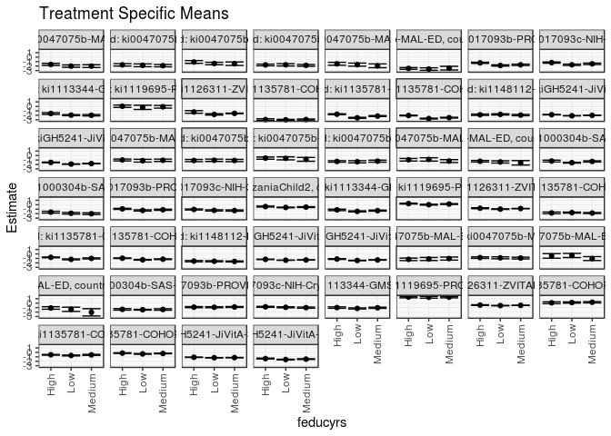

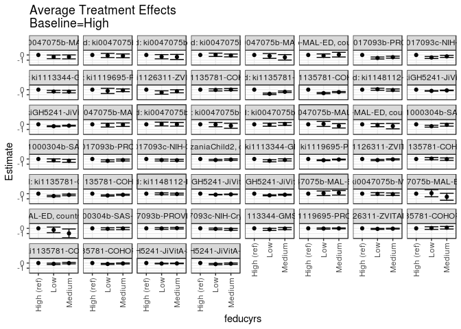

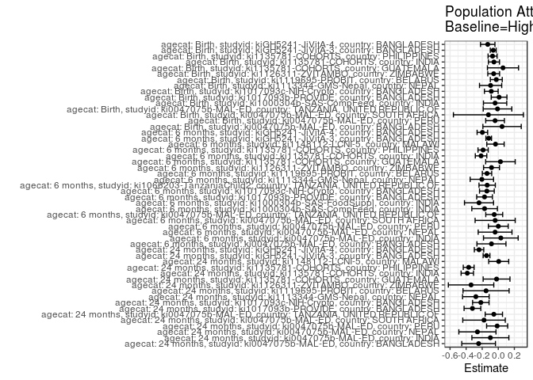

## Results Table

### Parameter: TSM

| agecat | studyid | country | intervention_level | baseline_level | estimate | ci_lower | ci_upper |
| --- | --- | --- | --- | --- | --- | --- | --- |
| Birth | ki0047075b-MAL-ED | BANGLADESH | High | NA | -1.2080181 | -1.4877860 | -0.9282502 |
| Birth | ki0047075b-MAL-ED | BANGLADESH | Low | NA | -1.1300103 | -1.4766041 | -0.7834165 |
| Birth | ki0047075b-MAL-ED | BANGLADESH | Medium | NA | -1.0362553 | -1.3813845 | -0.6911261 |
| Birth | ki0047075b-MAL-ED | PERU | High | NA | -0.8245624 | -0.9947866 | -0.6543381 |
| Birth | ki0047075b-MAL-ED | PERU | Low | NA | -0.8663125 | -1.0847155 | -0.6479095 |
| Birth | ki0047075b-MAL-ED | PERU | Medium | NA | -0.9273081 | -1.1238062 | -0.7308099 |
| Birth | ki0047075b-MAL-ED | SOUTH AFRICA | High | NA | -0.4350000 | -0.9433959 | 0.0733959 |
| Birth | ki0047075b-MAL-ED | SOUTH AFRICA | Low | NA | -0.3378571 | -0.8038006 | 0.1280863 |
| Birth | ki0047075b-MAL-ED | SOUTH AFRICA | Medium | NA | -1.0355556 | -1.4792485 | -0.5918626 |
| Birth | ki0047075b-MAL-ED | TANZANIA, UNITED REPUBLIC OF | High | NA | -1.0811287 | -1.3617359 | -0.8005215 |
| Birth | ki0047075b-MAL-ED | TANZANIA, UNITED REPUBLIC OF | Low | NA | -1.3808730 | -1.8538877 | -0.9078582 |
| Birth | ki0047075b-MAL-ED | TANZANIA, UNITED REPUBLIC OF | Medium | NA | -2.0559413 | -2.8657218 | -1.2461608 |
| Birth | ki1000304b-SAS-CompFeed | INDIA | High | NA | -1.3902829 | -1.5583177 | -1.2222482 |
| Birth | ki1000304b-SAS-CompFeed | INDIA | Low | NA | -1.4745654 | -1.5634357 | -1.3856951 |
| Birth | ki1000304b-SAS-CompFeed | INDIA | Medium | NA | -1.4157996 | -1.5734007 | -1.2581986 |
| Birth | ki1017093b-PROVIDE | BANGLADESH | High | NA | -0.8950456 | -1.0225371 | -0.7675541 |
| Birth | ki1017093b-PROVIDE | BANGLADESH | Low | NA | -0.9174817 | -1.0348307 | -0.8001328 |
| Birth | ki1017093b-PROVIDE | BANGLADESH | Medium | NA | -0.8580636 | -0.9686853 | -0.7474420 |
| Birth | ki1017093c-NIH-Crypto | BANGLADESH | High | NA | -0.8224634 | -0.9347701 | -0.7101567 |
| Birth | ki1017093c-NIH-Crypto | BANGLADESH | Low | NA | -0.9279803 | -1.0423554 | -0.8136052 |
| Birth | ki1017093c-NIH-Crypto | BANGLADESH | Medium | NA | -1.0111135 | -1.1481344 | -0.8740926 |
| Birth | ki1113344-GMS-Nepal | NEPAL | High | NA | -0.9931376 | -1.1541844 | -0.8320909 |
| Birth | ki1113344-GMS-Nepal | NEPAL | Low | NA | -1.1888419 | -1.3106790 | -1.0670049 |
| Birth | ki1113344-GMS-Nepal | NEPAL | Medium | NA | -1.0330219 | -1.1697783 | -0.8962654 |
| Birth | ki1119695-PROBIT | BELARUS | High | NA | 1.3605625 | 1.1988490 | 1.5222760 |
| Birth | ki1119695-PROBIT | BELARUS | Low | NA | 1.3210748 | 1.1277035 | 1.5144462 |
| Birth | ki1119695-PROBIT | BELARUS | Medium | NA | 1.3487141 | 1.1916199 | 1.5058082 |
| Birth | ki1126311-ZVITAMBO | ZIMBABWE | High | NA | -0.4406299 | -0.5170326 | -0.3642273 |
| Birth | ki1126311-ZVITAMBO | ZIMBABWE | Low | NA | -0.5436783 | -0.5983836 | -0.4889729 |
| Birth | ki1126311-ZVITAMBO | ZIMBABWE | Medium | NA | -0.4964241 | -0.5208026 | -0.4720455 |

[output cut: 126 more lines]

### Parameter: E(Y)

| agecat | studyid | country | intervention_level | baseline_level | estimate | ci_lower | ci_upper |
| --- | --- | --- | --- | --- | --- | --- | --- |
| Birth | ki0047075b-MAL-ED | BANGLADESH | NA | NA | -1.1609302 | -1.3461119 | -0.9757486 |
| Birth | ki0047075b-MAL-ED | PERU | NA | NA | -0.8645361 | -0.9887014 | -0.7403707 |
| Birth | ki0047075b-MAL-ED | SOUTH AFRICA | NA | NA | -0.5575758 | -0.8541170 | -0.2610345 |
| Birth | ki0047075b-MAL-ED | TANZANIA, UNITED REPUBLIC OF | NA | NA | -1.0906796 | -1.3207118 | -0.8606474 |
| Birth | ki1000304b-SAS-CompFeed | INDIA | NA | NA | -1.4300160 | -1.5090211 | -1.3510109 |
| Birth | ki1017093b-PROVIDE | BANGLADESH | NA | NA | -0.8851020 | -0.9601332 | -0.8100709 |
| Birth | ki1017093c-NIH-Crypto | BANGLADESH | NA | NA | -0.9094945 | -0.9809370 | -0.8380521 |
| Birth | ki1113344-GMS-Nepal | NEPAL | NA | NA | -1.0885159 | -1.1686181 | -1.0084136 |
| Birth | ki1119695-PROBIT | BELARUS | NA | NA | 1.3357134 | 1.1759964 | 1.4954304 |
| Birth | ki1126311-ZVITAMBO | ZIMBABWE | NA | NA | -0.4977261 | -0.5185420 | -0.4769102 |
| Birth | ki1135781-COHORTS | GUATEMALA | NA | NA | 0.1369030 | 0.0500914 | 0.2237146 |
| Birth | ki1135781-COHORTS | INDIA | NA | NA | -0.6011965 | -0.6594222 | -0.5429708 |
| Birth | ki1135781-COHORTS | PHILIPPINES | NA | NA | -0.2407379 | -0.2807613 | -0.2007145 |
| Birth | kiGH5241-JiVitA-3 | BANGLADESH | NA | NA | -1.1656619 | -1.1941706 | -1.1371531 |
| Birth | kiGH5241-JiVitA-4 | BANGLADESH | NA | NA | -1.5242226 | -1.5742923 | -1.4741529 |
| 6 months | ki0047075b-MAL-ED | BANGLADESH | NA | NA | -1.0793561 | -1.2238184 | -0.9348937 |
| 6 months | ki0047075b-MAL-ED | INDIA | NA | NA | -1.0814372 | -1.2260563 | -0.9368181 |
| 6 months | ki0047075b-MAL-ED | NEPAL | NA | NA | -0.6134211 | -0.7965750 | -0.4302671 |
| 6 months | ki0047075b-MAL-ED | PERU | NA | NA | -1.3245982 | -1.4425874 | -1.2066090 |
| 6 months | ki0047075b-MAL-ED | SOUTH AFRICA | NA | NA | -0.9833877 | -1.1756113 | -0.7911640 |
| 6 months | ki0047075b-MAL-ED | TANZANIA, UNITED REPUBLIC OF | NA | NA | -1.3283002 | -1.4654809 | -1.1911194 |
| 6 months | ki1000304b-SAS-CompFeed | INDIA | NA | NA | -1.4006377 | -1.4802862 | -1.3209891 |
| 6 months | ki1000304b-SAS-FoodSuppl | INDIA | NA | NA | -1.8986842 | -2.0118892 | -1.7854792 |
| 6 months | ki1017093b-PROVIDE | BANGLADESH | NA | NA | -1.0916915 | -1.1661176 | -1.0172654 |
| 6 months | ki1017093c-NIH-Crypto | BANGLADESH | NA | NA | -1.1986783 | -1.2700937 | -1.1272630 |
| 6 months | ki1066203-TanzaniaChild2 | TANZANIA, UNITED REPUBLIC OF | NA | NA | -0.5442042 | -0.5932639 | -0.4951446 |
| 6 months | ki1113344-GMS-Nepal | NEPAL | NA | NA | -1.3525459 | -1.4308373 | -1.2742545 |
| 6 months | ki1119695-PROBIT | BELARUS | NA | NA | 0.1181349 | 0.0244298 | 0.2118400 |
| 6 months | ki1126311-ZVITAMBO | ZIMBABWE | NA | NA | -0.8606958 | -0.8865994 | -0.8347923 |
| 6 months | ki1135781-COHORTS | GUATEMALA | NA | NA | -1.8074115 | -1.8776669 | -1.7371562 |
| 6 months | ki1135781-COHORTS | INDIA | NA | NA | -0.9755018 | -1.0332483 | -0.9177553 |
| 6 months | ki1135781-COHORTS | PHILIPPINES | NA | NA | -1.1419345 | -1.1847445 | -1.0991244 |
| 6 months | ki1148112-LCNI-5 | MALAWI | NA | NA | -1.6442734 | -1.7137349 | -1.5748119 |
| 6 months | kiGH5241-JiVitA-3 | BANGLADESH | NA | NA | -1.3298034 | -1.3534367 | -1.3061701 |
| 6 months | kiGH5241-JiVitA-4 | BANGLADESH | NA | NA | -1.3420154 | -1.3798750 | -1.3041557 |
| 24 months | ki0047075b-MAL-ED | BANGLADESH | NA | NA | -1.8775641 | -2.0346758 | -1.7204524 |
| 24 months | ki0047075b-MAL-ED | INDIA | NA | NA | -1.8269318 | -1.9896129 | -1.6642507 |
| 24 months | ki0047075b-MAL-ED | NEPAL | NA | NA | -1.3417582 | -1.5289233 | -1.1545932 |
| 24 months | ki0047075b-MAL-ED | PERU | NA | NA | -1.7614634 | -1.8900568 | -1.6328700 |
| 24 months | ki0047075b-MAL-ED | SOUTH AFRICA | NA | NA | -1.6659341 | -1.8736055 | -1.4582627 |
| 24 months | ki0047075b-MAL-ED | TANZANIA, UNITED REPUBLIC OF | NA | NA | -2.5842090 | -2.7302958 | -2.4381223 |
| 24 months | ki1017093b-PROVIDE | BANGLADESH | NA | NA | -1.6024221 | -1.6857420 | -1.5191023 |
| 24 months | ki1017093c-NIH-Crypto | BANGLADESH | NA | NA | -1.4412646 | -1.5249156 | -1.3576135 |
| 24 months | ki1113344-GMS-Nepal | NEPAL | NA | NA | -1.8889117 | -1.9744778 | -1.8033456 |
| 24 months | ki1119695-PROBIT | BELARUS | NA | NA | -0.1248692 | -0.4220079 | 0.1722694 |
| 24 months | ki1126311-ZVITAMBO | ZIMBABWE | NA | NA | -1.5903795 | -1.6477380 | -1.5330211 |
| 24 months | ki1135781-COHORTS | GUATEMALA | NA | NA | -2.9834879 | -3.0503374 | -2.9166384 |
| 24 months | ki1135781-COHORTS | INDIA | NA | NA | -2.1479058 | -2.2089283 | -2.0868833 |
| 24 months | ki1135781-COHORTS | PHILIPPINES | NA | NA | -2.4268626 | -2.4728444 | -2.3808807 |
| 24 months | ki1148112-LCNI-5 | MALAWI | NA | NA | -1.8787566 | -1.9605168 | -1.7969964 |
| 24 months | kiGH5241-JiVitA-3 | BANGLADESH | NA | NA | -2.0128026 | -2.0405337 | -1.9850716 |
| 24 months | kiGH5241-JiVitA-4 | BANGLADESH | NA | NA | -1.7817125 | -1.8182569 | -1.7451681 |

### Parameter: ATE

| agecat | studyid | country | intervention_level | baseline_level | estimate | ci_lower | ci_upper |
| --- | --- | --- | --- | --- | --- | --- | --- |
| Birth | ki0047075b-MAL-ED | BANGLADESH | High | High | 0.0000000 | 0.0000000 | 0.0000000 |
| Birth | ki0047075b-MAL-ED | BANGLADESH | Low | High | 0.0780078 | -0.3685317 | 0.5245473 |
| Birth | ki0047075b-MAL-ED | BANGLADESH | Medium | High | 0.1717628 | -0.2738804 | 0.6174059 |
| Birth | ki0047075b-MAL-ED | PERU | High | High | 0.0000000 | 0.0000000 | 0.0000000 |
| Birth | ki0047075b-MAL-ED | PERU | Low | High | -0.0417501 | -0.2956584 | 0.2121582 |
| Birth | ki0047075b-MAL-ED | PERU | Medium | High | -0.1027457 | -0.3431863 | 0.1376949 |
| Birth | ki0047075b-MAL-ED | SOUTH AFRICA | High | High | 0.0000000 | 0.0000000 | 0.0000000 |
| Birth | ki0047075b-MAL-ED | SOUTH AFRICA | Low | High | 0.0971429 | -0.5924727 | 0.7867584 |
| Birth | ki0047075b-MAL-ED | SOUTH AFRICA | Medium | High | -0.6005556 | -1.2753368 | 0.0742257 |
| Birth | ki0047075b-MAL-ED | TANZANIA, UNITED REPUBLIC OF | High | High | 0.0000000 | 0.0000000 | 0.0000000 |
| Birth | ki0047075b-MAL-ED | TANZANIA, UNITED REPUBLIC OF | Low | High | -0.2997443 | -0.8500753 | 0.2505868 |
| Birth | ki0047075b-MAL-ED | TANZANIA, UNITED REPUBLIC OF | Medium | High | -0.9748126 | -1.8297776 | -0.1198476 |
| Birth | ki1000304b-SAS-CompFeed | INDIA | High | High | 0.0000000 | 0.0000000 | 0.0000000 |
| Birth | ki1000304b-SAS-CompFeed | INDIA | Low | High | -0.0842825 | -0.2774752 | 0.1089102 |
| Birth | ki1000304b-SAS-CompFeed | INDIA | Medium | High | -0.0255167 | -0.2497213 | 0.1986879 |
| Birth | ki1017093b-PROVIDE | BANGLADESH | High | High | 0.0000000 | 0.0000000 | 0.0000000 |
| Birth | ki1017093b-PROVIDE | BANGLADESH | Low | High | -0.0224361 | -0.1846808 | 0.1398086 |
| Birth | ki1017093b-PROVIDE | BANGLADESH | Medium | High | 0.0369820 | -0.1204430 | 0.1944070 |
| Birth | ki1017093c-NIH-Crypto | BANGLADESH | High | High | 0.0000000 | 0.0000000 | 0.0000000 |
| Birth | ki1017093c-NIH-Crypto | BANGLADESH | Low | High | -0.1055169 | -0.2623896 | 0.0513558 |
| Birth | ki1017093c-NIH-Crypto | BANGLADESH | Medium | High | -0.1886501 | -0.3624049 | -0.0148954 |
| Birth | ki1113344-GMS-Nepal | NEPAL | High | High | 0.0000000 | 0.0000000 | 0.0000000 |
| Birth | ki1113344-GMS-Nepal | NEPAL | Low | High | -0.1957043 | -0.3952995 | 0.0038909 |
| Birth | ki1113344-GMS-Nepal | NEPAL | Medium | High | -0.0398843 | -0.2489238 | 0.1691553 |
| Birth | ki1119695-PROBIT | BELARUS | High | High | 0.0000000 | 0.0000000 | 0.0000000 |
| Birth | ki1119695-PROBIT | BELARUS | Low | High | -0.0394877 | -0.1572396 | 0.0782642 |
| Birth | ki1119695-PROBIT | BELARUS | Medium | High | -0.0118485 | -0.1014072 | 0.0777103 |
| Birth | ki1126311-ZVITAMBO | ZIMBABWE | High | High | 0.0000000 | 0.0000000 | 0.0000000 |
| Birth | ki1126311-ZVITAMBO | ZIMBABWE | Low | High | -0.1030483 | -0.1964378 | -0.0096589 |
| Birth | ki1126311-ZVITAMBO | ZIMBABWE | Medium | High | -0.0557941 | -0.1352938 | 0.0237055 |

[output cut: 126 more lines]

### Parameter: PAR

| agecat | studyid | country | intervention_level | baseline_level | estimate | ci_lower | ci_upper |
| --- | --- | --- | --- | --- | --- | --- | --- |
| Birth | ki0047075b-MAL-ED | BANGLADESH | High | NA | 0.0470879 | -0.1912440 | 0.2854198 |
| Birth | ki0047075b-MAL-ED | PERU | High | NA | -0.0399737 | -0.1561466 | 0.0761992 |
| Birth | ki0047075b-MAL-ED | SOUTH AFRICA | High | NA | -0.1225758 | -0.5581866 | 0.3130351 |
| Birth | ki0047075b-MAL-ED | TANZANIA, UNITED REPUBLIC OF | High | NA | -0.0095509 | -0.1874015 | 0.1682997 |
| Birth | ki1000304b-SAS-CompFeed | INDIA | High | NA | -0.0397331 | -0.1845659 | 0.1050997 |
| Birth | ki1017093b-PROVIDE | BANGLADESH | High | NA | 0.0099436 | -0.0875917 | 0.1074789 |
| Birth | ki1017093c-NIH-Crypto | BANGLADESH | High | NA | -0.0870312 | -0.1723116 | -0.0017507 |
| Birth | ki1113344-GMS-Nepal | NEPAL | High | NA | -0.0953782 | -0.2335474 | 0.0427909 |
| Birth | ki1119695-PROBIT | BELARUS | High | NA | -0.0248491 | -0.0990635 | 0.0493653 |
| Birth | ki1126311-ZVITAMBO | ZIMBABWE | High | NA | -0.0570962 | -0.1305655 | 0.0163732 |
| Birth | ki1135781-COHORTS | GUATEMALA | High | NA | 0.0586384 | -0.1347545 | 0.2520313 |
| Birth | ki1135781-COHORTS | INDIA | High | NA | -0.0536535 | -0.1227080 | 0.0154010 |
| Birth | ki1135781-COHORTS | PHILIPPINES | High | NA | -0.0711649 | -0.1270684 | -0.0152613 |
| Birth | kiGH5241-JiVitA-3 | BANGLADESH | High | NA | -0.0628538 | -0.0995433 | -0.0261643 |
| Birth | kiGH5241-JiVitA-4 | BANGLADESH | High | NA | -0.1312199 | -0.2209024 | -0.0415375 |
| 6 months | ki0047075b-MAL-ED | BANGLADESH | High | NA | -0.0848694 | -0.2654020 | 0.0956633 |
| 6 months | ki0047075b-MAL-ED | INDIA | High | NA | 0.0318731 | -0.1837275 | 0.2474737 |
| 6 months | ki0047075b-MAL-ED | NEPAL | High | NA | -0.0396834 | -0.2498125 | 0.1704457 |
| 6 months | ki0047075b-MAL-ED | PERU | High | NA | 0.0001735 | -0.1230770 | 0.1234240 |
| 6 months | ki0047075b-MAL-ED | SOUTH AFRICA | High | NA | -0.0387997 | -0.2882144 | 0.2106150 |
| 6 months | ki0047075b-MAL-ED | TANZANIA, UNITED REPUBLIC OF | High | NA | -0.0503144 | -0.1554517 | 0.0548229 |
| 6 months | ki1000304b-SAS-CompFeed | INDIA | High | NA | -0.1701512 | -0.3292059 | -0.0110966 |
| 6 months | ki1000304b-SAS-FoodSuppl | INDIA | High | NA | -0.2397085 | -0.4203280 | -0.0590890 |
| 6 months | ki1017093b-PROVIDE | BANGLADESH | High | NA | -0.1706495 | -0.2682705 | -0.0730285 |
| 6 months | ki1017093c-NIH-Crypto | BANGLADESH | High | NA | -0.1417327 | -0.2332560 | -0.0502094 |
| 6 months | ki1066203-TanzaniaChild2 | TANZANIA, UNITED REPUBLIC OF | High | NA | -0.1383067 | -0.2398800 | -0.0367335 |
| 6 months | ki1113344-GMS-Nepal | NEPAL | High | NA | -0.2041412 | -0.3493892 | -0.0588932 |
| 6 months | ki1119695-PROBIT | BELARUS | High | NA | -0.1401279 | -0.1984786 | -0.0817772 |
| 6 months | ki1126311-ZVITAMBO | ZIMBABWE | High | NA | -0.0839496 | -0.1828254 | 0.0149262 |
| 6 months | ki1135781-COHORTS | GUATEMALA | High | NA | 0.0268779 | -0.1567811 | 0.2105368 |
| 6 months | ki1135781-COHORTS | INDIA | High | NA | -0.2142476 | -0.2857785 | -0.1427166 |
| 6 months | ki1135781-COHORTS | PHILIPPINES | High | NA | -0.1887457 | -0.2523179 | -0.1251735 |
| 6 months | ki1148112-LCNI-5 | MALAWI | High | NA | -0.0348137 | -0.1428256 | 0.0731982 |
| 6 months | kiGH5241-JiVitA-3 | BANGLADESH | High | NA | -0.1191204 | -0.1539420 | -0.0842988 |
| 6 months | kiGH5241-JiVitA-4 | BANGLADESH | High | NA | -0.1977771 | -0.2633635 | -0.1321907 |
| 24 months | ki0047075b-MAL-ED | BANGLADESH | High | NA | -0.2445525 | -0.4539655 | -0.0351396 |
| 24 months | ki0047075b-MAL-ED | INDIA | High | NA | -0.0981722 | -0.3282072 | 0.1318627 |
| 24 months | ki0047075b-MAL-ED | NEPAL | High | NA | -0.2594187 | -0.4903811 | -0.0284562 |
| 24 months | ki0047075b-MAL-ED | PERU | High | NA | -0.0141058 | -0.1452304 | 0.1170187 |
| 24 months | ki0047075b-MAL-ED | SOUTH AFRICA | High | NA | -0.1772489 | -0.4415436 | 0.0870458 |
| 24 months | ki0047075b-MAL-ED | TANZANIA, UNITED REPUBLIC OF | High | NA | -0.0551673 | -0.1629189 | 0.0525843 |
| 24 months | ki1017093b-PROVIDE | BANGLADESH | High | NA | -0.3214473 | -0.4254010 | -0.2174936 |
| 24 months | ki1017093c-NIH-Crypto | BANGLADESH | High | NA | -0.2171186 | -0.3195156 | -0.1147216 |
| 24 months | ki1113344-GMS-Nepal | NEPAL | High | NA | -0.2788459 | -0.4440880 | -0.1136037 |
| 24 months | ki1119695-PROBIT | BELARUS | High | NA | -0.1518792 | -0.4385431 | 0.1347847 |
| 24 months | ki1126311-ZVITAMBO | ZIMBABWE | High | NA | -0.3384101 | -0.6210179 | -0.0558023 |
| 24 months | ki1135781-COHORTS | GUATEMALA | High | NA | -0.0213018 | -0.1880261 | 0.1454225 |
| 24 months | ki1135781-COHORTS | INDIA | High | NA | -0.3853312 | -0.4623566 | -0.3083057 |
| 24 months | ki1135781-COHORTS | PHILIPPINES | High | NA | -0.3682255 | -0.4354540 | -0.3009971 |
| 24 months | ki1148112-LCNI-5 | MALAWI | High | NA | 0.0052839 | -0.1192846 | 0.1298524 |
| 24 months | kiGH5241-JiVitA-3 | BANGLADESH | High | NA | -0.1461161 | -0.1880616 | -0.1041705 |
| 24 months | kiGH5241-JiVitA-4 | BANGLADESH | High | NA | -0.2392638 | -0.2977824 | -0.1807451 |